# a_cand_XER_MMI_crs_valid

C. Emi Fergus

2024-01-29

## Compare candidate model predictive performance

We are interested in developing models that will allow for predicting changes in MMI scores under hypothetical management scenarios. We will evaluate the models based on their predictive performance (RMSE & R2). There may be benefits to using modeling approaches that allow for causal inference.

# Apply candidate model prediction function

Check by calling “index_value =1” to make sure function is working

```
##      obs       mlr       sem        sp        rf      rfsp
## 1 0.7390 0.4728426 0.4527950 0.4648315 0.4907284 0.4829052
## 2 0.7196 0.5788424 0.5622104 0.5498044 0.5419987 0.5391490
## 3 0.5047 0.4816527 0.4648387 0.4807275 0.5274486 0.5441758
## 4 0.3829 0.3664797 0.3863050 0.3823672 0.4212976 0.4507116
## 5 0.3213 0.3133959 0.2817295 0.3116765 0.3371689 0.3486812
## 6 0.2654 0.3954553 0.3788080 0.3695489 0.3559113 0.3425666
```

# 10-Fold Cross Validation

Apply the candidate model prediction function across index values. Each observation is assigned a group (index) number. This will allow us to systematically hold out part of the observations to test model fit. With k-fold cross-validation, we will evaluate the predictive performance multiple times using the full set of observations by cycling through the index values by specifying a test dataset based on the index value and treating the remaining groups as the training dataset. Each observation will be used in the test data 1 time and used the train the model k-1 times. 10-fold cross validation.

The function also allows us to compare untransformed O/E vs log10 OE.

# Evaluate relative model performance using RMSE and R2

# RMSE across candidate models

```
##   Models  RMSE
## 1    mlr 0.152
## 2    sem 0.151
## 3     sp 0.152
## 4     rf 0.153
## 5   rfsp 0.153
```

# R2

```
##   Models    R2
## 1    mlr 0.433
## 2    sem 0.440
## 3     sp 0.439
## 4     rf 0.440
## 5   rfsp 0.434
```

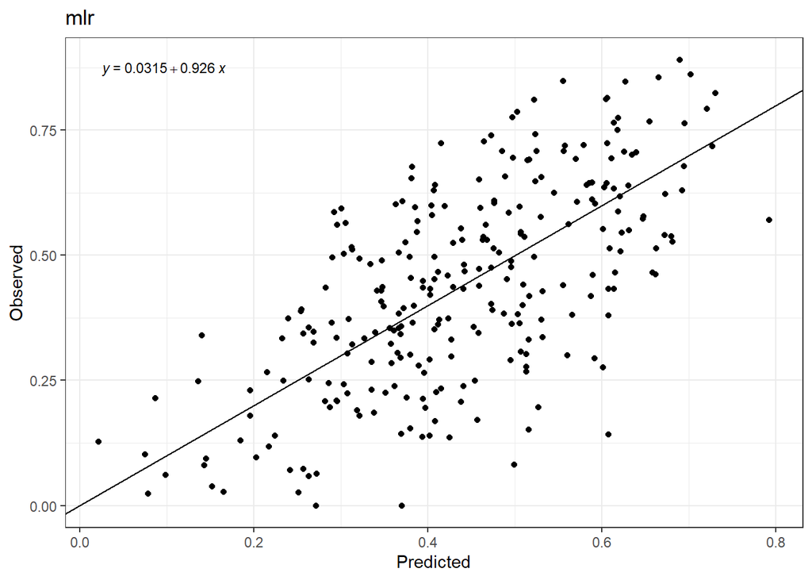

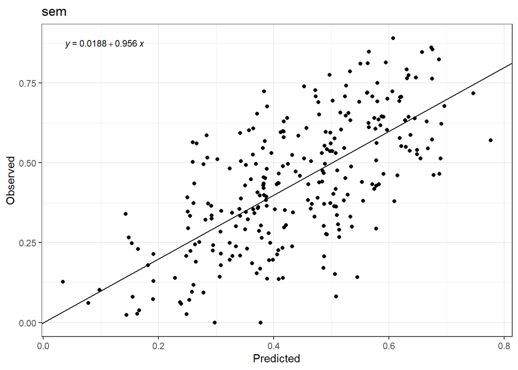

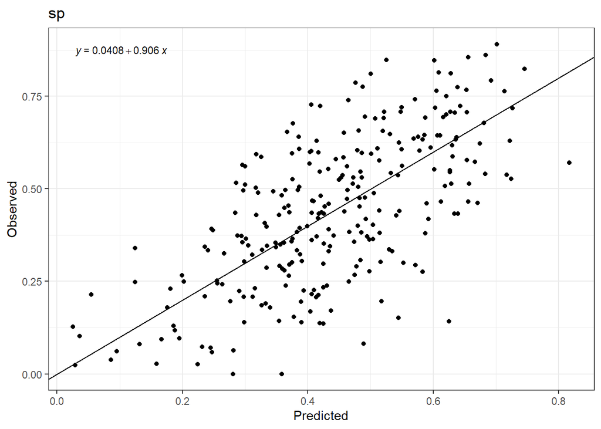

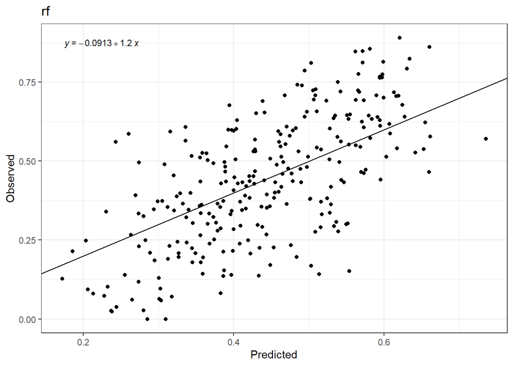